# Fashion MNIST

**Group Member 1 Name:** Ian Driscoll **Group Member 1 SID:** 3031896752

The dataset contains $n=18,000$ different $28\times 28$ grayscale images of clothing, each with a label of either *shoes*, *shirt*, or *pants* (6000 of each). If we stack the features into a single vector, we can transform each of these observations into a single $28*28 = 784$ dimensional vector. The data can thus be stored in a $n\times p = 18000\times 784$ data matrix $\mathbf{X}$, and the labels stored in a $n\times 1$ vector $\mathbf{y}$.

Once downloaded, the data can be read as follows.

```r
library(readr)
FMNIST <- read_csv("FashionMNIST.csv")
```

```r
y <- FMNIST$label
X <- subset(FMNIST, select = -c(label))
#rm('FMNIST') #remove from memory -- it's a relatively large file
print(dim(X))
```

We can look at a few of the images:

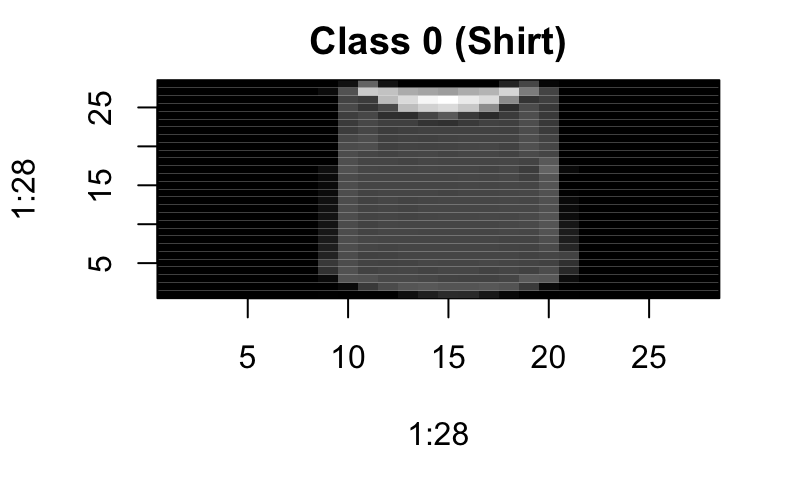

# Data exploration and dimension reduction

In this step, I will use PCA in order to reduces the dimensions of this dataset.

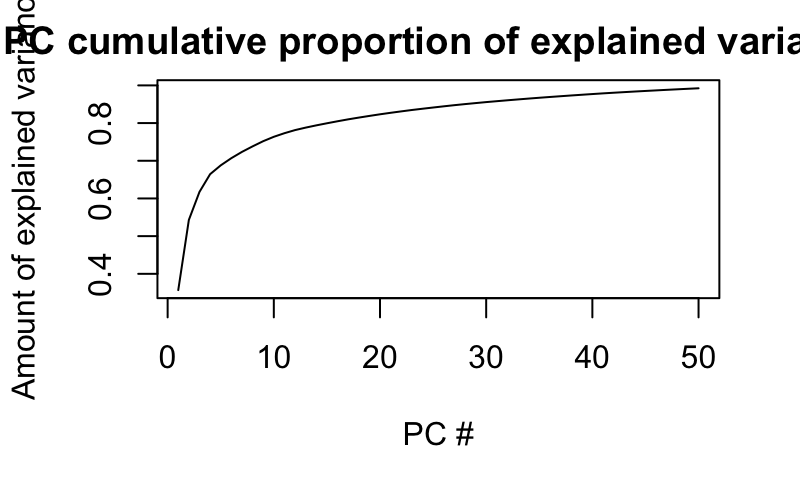

```r
library(MASS)
pca = prcomp(X)
importance = summary(pca)
cumprop = cumsum(importance$sdev^2 / sum(importance$sdev^2))
plot(cumprop[0:50],
     xlab = "PC #",
     ylab = "Amount of explained variance",
     main = "PC cumulative proportion of explained variance",
     type="l")
```

```r
cumprop[49]
```

```
[1] 0.8910128
```

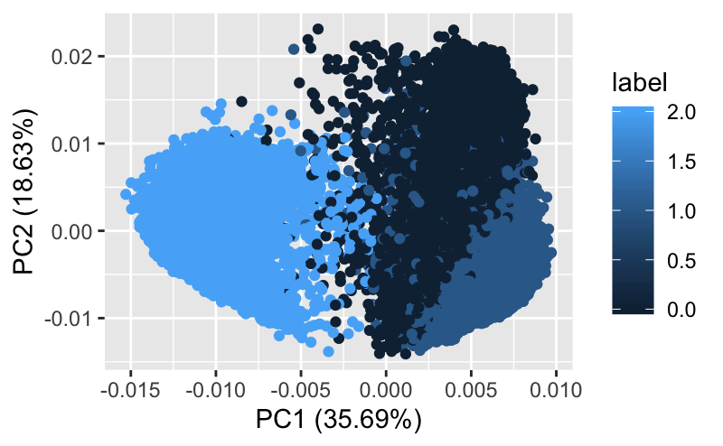

```r
reducedX = data.frame(pca$x[,1:49])
library(ggfortify)
data = data.frame(FMNIST)
autoplot(pca, data = data, colour = 'label',)
```

By applying PCA and inspecting the scree plot, we can see that about 90% of the variance is explained by the first 50 PCs. If we think about this logically, we can think of that as a 7 by 7 grid by including 49 PCs, which is reducing the dimensions overall by a factor of 16. Including 49 components accounts for approximately 89.1% of the variance. Additionally, in the plot above, we can see that the first two PCs alone display a bit of separation between the three classes.

# Classification task

## Binary classification

Our first step will be to split our dataset into a training set and test set. I will use the proportion of 75/25.

```r
smp_size <- floor(0.75 * nrow(reducedX))

set.seed(123)
train_ind = sample(seq_len(nrow(reducedX)), size = smp_size)

trainX = reducedX[train_ind, ]
testX = reducedX[-train_ind, ]
trainY = y[train_ind]
testY = y[-train_ind]
```

```r
m1
```

[output not shown]

```r
trainX02 = trainX[trainY != 1,]
testX02 = testX[testY != 1,]
trainY02 = trainY[trainY != 1]
testY02 = testY[testY != 1]

# KNN
library(class)
library(caret)
train = data.frame(trainX02, "class"=trainY02)
test = data.frame(testX02, "class"=testY02)
output = knn(train, test, cl=trainY02)
confusionMatrix(as.factor(output), as.factor(testY02))
```

```
Confusion Matrix and Statistics

          Reference
Prediction    0    2
         0 1475    0
         2    0 1523

               Accuracy : 1
                 95% CI : (0.9988, 1)
    No Information Rate : 0.508
    P-Value [Acc > NIR] : < 2.2e-16

                  Kappa : 1

 Mcnemar's Test P-Value : NA

            Sensitivity : 1.000
            Specificity : 1.000
         Pos Pred Value : 1.000
         Neg Pred Value : 1.000
             Prevalence : 0.492
         Detection Rate : 0.492
   Detection Prevalence : 0.492
      Balanced Accuracy : 1.000

       'Positive' Class : 0
```

```r
library(randomForest)
m1 = randomForest(
  formula = class ~ .,
  x = train[,1:49],
  y = as.factor(train[,50]),
  data = train,
  xtest = testX02,
  ytest = as.factor(testY02)
)

m1
```

```
Call:
 randomForest(x = train[, 1:49], y = as.factor(train[, 50]), xtest = testX02,      ytest = as.factor(testY02), formula = class ~ ., data = train)
               Type of random forest: classification
                     Number of trees: 500
No. of variables tried at each split: 7

        OOB estimate of  error rate: 0.17%
Confusion matrix:
     0    2 class.error
0 4519    6 0.001325967
2    9 4468 0.002010275
                Test set error rate: 0.07%
Confusion matrix:
     0    2 class.error
0 1475    0 0.000000000
2    2 1521 0.001313198
```

Finally, we will look at pants(1) and shoes(2).

```r
trainX12 = trainX[trainY != 0,]
testX12 = testX[testY != 0,]
trainY12 = trainY[trainY != 0]
testY12 = testY[testY != 0]

# KNN
library(class)
library(caret)
train = data.frame(trainX12, "class"=trainY12)
test = data.frame(testX12, "class"=testY12)
output = knn(train, test, cl=trainY12)
confusionMatrix(as.factor(output), as.factor(testY12))
```

```
Confusion Matrix and Statistics

          Reference
Prediction    1    2
         1 1501    0
         2    1 1523

               Accuracy : 0.9997
                 95% CI : (0.9982, 1)
    No Information Rate : 0.5035
    P-Value [Acc > NIR] : <2e-16

                  Kappa : 0.9993

 Mcnemar's Test P-Value : 1

            Sensitivity : 0.9993
            Specificity : 1.0000
         Pos Pred Value : 1.0000
         Neg Pred Value : 0.9993
             Prevalence : 0.4965
         Detection Rate : 0.4962
   Detection Prevalence : 0.4962
      Balanced Accuracy : 0.9997

       'Positive' Class : 1
```

```r
library(randomForest)
m1 = randomForest(
  formula = class ~ .,
  x = train[,1:49],
  y = as.factor(train[,50]),
  data = train,
  xtest = testX12,
  ytest = as.factor(testY12)
)

m1
```

```
Call:
 randomForest(x = train[, 1:49], y = as.factor(train[, 50]), xtest = testX12,      ytest = as.factor(testY12), formula = class ~ ., data = train)
               Type of random forest: classification
                     Number of trees: 500
No. of variables tried at each split: 7

        OOB estimate of  error rate: 0.06%
Confusion matrix:
     1    2  class.error
1 4497    1 0.0002223210
2    4 4473 0.0008934554
                Test set error rate: 0.17%
Confusion matrix:
     1    2 class.error
1 1499    3 0.001997337
2    2 1521 0.001313198
```

## Multiclass classification

Examining the binary classification, we can see that both models perform very highly on our training data. We will use both KNN and Random Forest to apply a multiclass classifier to our entire dataset. In order to validate our performance, we will use 10-fold cross validation, splitting the data into 10 folds and using the Leave-One-Out method of training/testing.

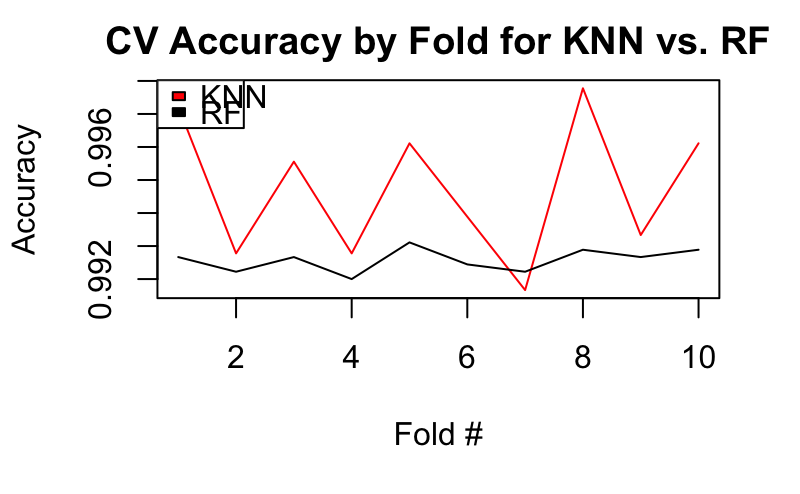

```r
plot(accs_knn, type="l", col="red",
     main="CV Accuracy by Fold for KNN vs. RF",
     xlab="Fold #", ylab="Accuracy")
lines(accs_rf)
legend("topleft", c("KNN","RF"), fill=c("red", "black"))
paste0("KNN CV 10 fold average accuracy: ", toString(mean(accs_knn)))
```

```
[1] "KNN CV 10 fold average accuracy: 0.994722222222222"
```

```r
paste0("RF CV 10 fold average accuracy: ", toString(mean(accs_rf)))
```

```
[1] "RF CV 10 fold average accuracy: 0.992577777777778"
```

We can see that averaged across all folds, the K-Nearest Neighbors classifier performs slightly higher than the Random Forest classifier. Therefore, our optimal model will be a K-Nearest Neighbors classifier built on the reduced dataset we obtained with the first 49 Principal Components.